# **Loan Default Prediction**

### **Building a Random Forest Classifier**

**Random Forest is a bagging algorithm where the base models are Decision Trees.** Samples are taken from the training data and on each sample a decision tree makes a prediction.

**The results from all the decision trees are combined together and the final prediction is made using voting or averaging.**

```python
# Fitting the Random Forest classifier on the training data
rf_estimator = RandomForestClassifier(class_weight = {0: 0.20, 1: 0.80}, random_state = 1)

rf_estimator.fit(x_train, y_train)
```

```
RandomForestClassifier(class_weight={0: 0.2, 1: 0.8}, random_state=1)
```

```python
# Checking performance on the training data
y_pred_train_rf = rf_estimator.predict(x_train)

metrics_score(y_train, y_pred_train_rf)
```

```
              precision    recall  f1-score   support

           0       1.00      1.00      1.00      3340
           1       1.00      1.00      1.00       832

    accuracy                           1.00      4172
   macro avg       1.00      1.00      1.00      4172
weighted avg       1.00      1.00      1.00      4172
```

```
              precision    recall  f1-score   support

           0       0.91      0.97      0.94      1431
           1       0.84      0.60      0.70       357

    accuracy                           0.90      1788
   macro avg       0.87      0.79      0.82      1788
weighted avg       0.89      0.90      0.89      1788
```

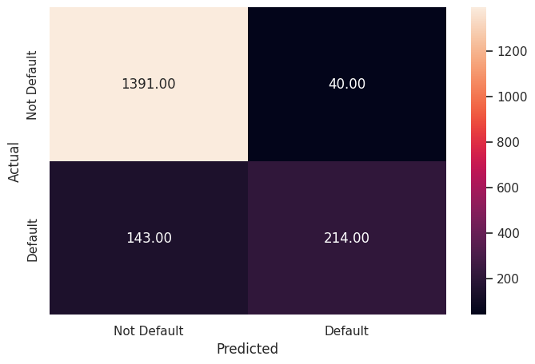

```python
# Checking performance on the testing data
y_pred_test_rf = rf_estimator.predict(x_test)

metrics_score(y_test, y_pred_test_rf)
```

```python
# Checking performance on the TRAINING SET
model_performance_classification(rf_estimator, x_train, y_train)
```

|  | Precision | Recall | Accuracy |
| --- | --- | --- | --- |
| 0 | 1.0 | 1.0 | 1.0 |

```python
# Checking performance on the TEST SET
rf_estimator_test = model_performance_classification(rf_estimator,x_test,y_test)
rf_estimator_test
```

|  | Precision | Recall | Accuracy |
| --- | --- | --- | --- |
| 0 | 0.87465 | 0.785744 | 0.897651 |

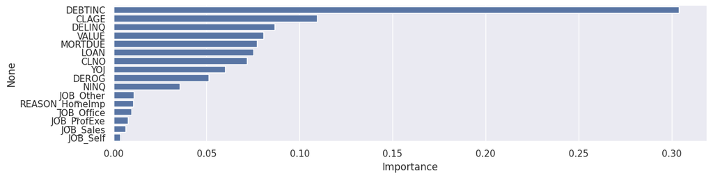

```python
#Check importance of features

importances = rf_estimator.feature_importances_

columns = X.columns

importance_df = pd.DataFrame(importances, index = columns, columns = ['Importance']).sort_values(by = 'Importance', ascending = False)

plt.figure(figsize = (13, 3))

sns.barplot(x= importance_df.Importance, y=importance_df.index);
```

### **Random Forest Classifier Hyperparameter Tuning**

```python
#Tuning the model

%%time
# Choose the type of classifier
rf_estimator_tuned = RandomForestClassifier(class_weight = {0: 0.20, 1: 0.80}, random_state = 1)

# Grid of parameters to choose from
params_rf = {"n_estimators": [100, 250, 500],
             "min_samples_leaf": np.arange(1, 4, 1),
             "max_features": [0.7, 0.9, 'auto']}

# Type of scoring used to compare parameter combinations - recall score for class 1
scorer = metrics.make_scorer(precision_score, pos_label = 1)

# Run the grid search
grid_obj = GridSearchCV(rf_estimator_tuned, params_rf, scoring = scorer, cv = 5)

grid_obj = grid_obj.fit(x_train, y_train)

# Set the classifier to the best combination of parameters
rf_estimator_tuned = grid_obj.best_estimator_
```

```
CPU times: user 9min 4s, sys: 940 ms, total: 9min 5s
Wall time: 10min 33s
```

```python
rf_estimator_tuned.fit(x_train, y_train)
```

```
RandomForestClassifier(class_weight={0: 0.2, 1: 0.8}, max_features='auto',
                       n_estimators=250, random_state=1)
```

```python
# Checking performance on the training data
y_pred_train_rf_tuned = rf_estimator_tuned.predict(x_train)

metrics_score(y_train, y_pred_train_rf_tuned)
```

```
              precision    recall  f1-score   support

           0       1.00      1.00      1.00      3340
           1       1.00      1.00      1.00       832

    accuracy                           1.00      4172
   macro avg       1.00      1.00      1.00      4172
weighted avg       1.00      1.00      1.00      4172
```

```
              precision    recall  f1-score   support

           0       0.91      0.97      0.94      1431
           1       0.86      0.62      0.72       357

    accuracy                           0.90      1788
   macro avg       0.88      0.80      0.83      1788
weighted avg       0.90      0.90      0.90      1788
```

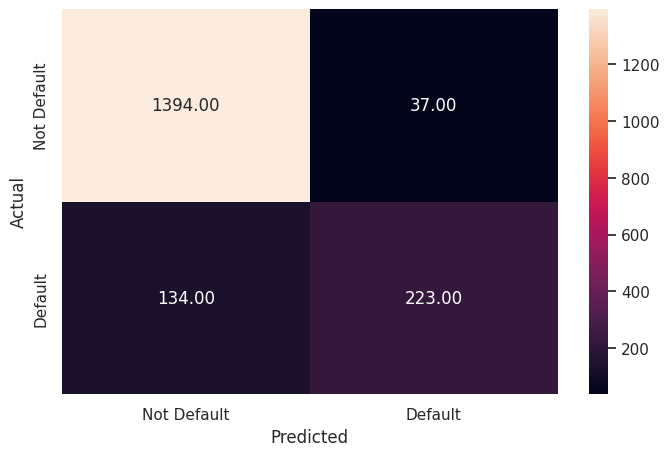

```python
# Checking performance on the test data
y_pred_test_rf_tuned = rf_estimator_tuned.predict(x_test)

metrics_score(y_test, y_pred_test_rf_tuned)
```

```python
# Checking performance on the TRAINING SET
model_performance_classification(rf_estimator_tuned, x_train, y_train)
```

|  | Precision | Recall | Accuracy |
| --- | --- | --- | --- |
| 0 | 1.0 | 1.0 | 1.0 |

```python
# Checking performance on the TEST SET
rf_estimator_tuned_test = model_performance_classification(rf_estimator_tuned, x_test, y_test)
rf_estimator_tuned_test
```

|  | Precision | Recall | Accuracy |
| --- | --- | --- | --- |
| 0 | 0.884998 | 0.799397 | 0.904362 |

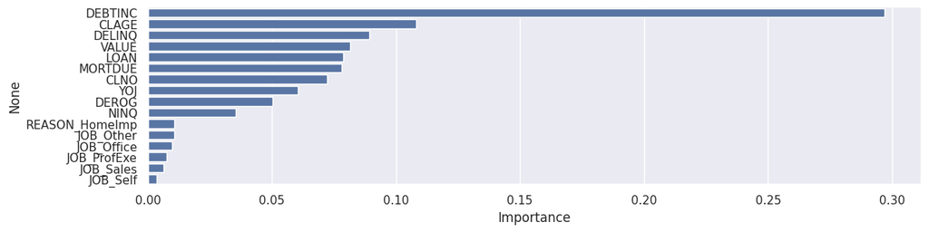

```python
# Plotting feature importance
importances = rf_estimator_tuned.feature_importances_

columns = X.columns

importance_df = pd.DataFrame(importances, index = columns, columns = ['Importance']).sort_values(by = 'Importance', ascending = False)

plt.figure(figsize = (13, 3))

sns.barplot(x= importance_df.Importance, y= importance_df.index)
```

**1. Comparison of various techniques and their relative performance based on chosen Metric (Measure of success):**

- How do different techniques perform? Which one is performing relatively better? Is there scope to improve the performance further?

```python
models_test_comp_df = pd.concat([logreg_test.T,
                                 dtree_test.T,
                                 dtree_tuned_test.T,
                                 rf_estimator_test.T,
                                 rf_estimator_tuned_test.T], axis = 1)

models_test_comp_df.columns = ["Regression classifier",
                               "Decision Tree classifier",
                               "Tuned Decision Tree classifier",
                               "Random Forest classifier",
                               "Tuned Random Forest classifier"]

print("Test performance comparison:")
models_test_comp_df.T
```

```
Test performance comparison:
```

[output not shown]

**2. Refined insights:**

- What are the most meaningful insights relevant to the problem?

The best performing models are the Tuned Random Forest and the Tuned Decision Tree.

There is a tradeoff between model performance and interpretability. While the Random Forest models perform better, Decision Trees are more interpretable.

**3. Proposal for the final solution design:**

- What model do you propose to be adopted? Why is this the best solution to adopt?

Proposed Model:

Tuned Random Forest Classifier

Why:

Precision and Recall: The high precision means fewer false positives, reducing the risk of incorrectly identifying non-defaulters as defaulters. The reasonably high recall indicates a good balance in identifying actual defaulters.

Accuracy: The high accuracy confirms the model's overall reliability.

**Tradeoff between Model Performance and Interpretability:**

The Tuned Random Forest offers superior predictive performance but is less interpretable compared to a Decision Tree.

To balance this, a Decision Tree model can be used alongside for interpretability. This can help explain individual predictions made by the Random Forest model.

# Executive Summary

The objective of this project was to develop a machine learning model to predict loan defaults for a bank's home equity lines of credit. Given the high stakes involved in loan defaults, a model that accurately predicts which clients are likely to default is crucial for maintaining financial stability and compliance with regulatory standards.

**Key Findings:**

- Trade-off Considerations:

A Decision Tree model can be used in parallel to provide interpretability, balancing the need for performance and explainability.

**Final Model Specifications:**

- Model Chosen: Tuned Random Forest Classifier
- Metrics: Precision (0.884998), Recall (0.799397), Accuracy (0.904362)
- Complementary Model: Decision Tree for interpretability

**Next Steps:**

Implement the Tuned Random Forest model in the bank’s decision-making process. Use the Decision Tree model to interpret and explain individual predictions. Monitor model performance regularly and retrain as necessary to maintain accuracy and compliance.

# Problem and Solution Summary

**Problem Summary:**

A significant portion of retail bank profit is derived from interest on home loans, but bad loans (NPAs) can drastically reduce profitability. The current manual loan approval process is not only labor-intensive but also prone to human errors and biases. Automating this process using machine learning aims to enhance efficiency and fairness while reducing defaults.

Key Points of Proposed Solution:

- Model Selection: After evaluating various models, the Tuned Random Forest Classifier was selected due to its superior performance in predicting defaults.
- Performance Metrics: Precision (0.884998), Recall (0.799397), and Accuracy (0.904362) indicate the model's effectiveness.
- Interpretability: Using a Decision Tree alongside provides necessary insights into the decision-making process.

**Impact on Business:**

- Reduced Defaults: Accurate predictions will lead to fewer bad loans, improving the bank's financial health.
- Efficiency: Automating the approval process reduces operational costs and time.
- Fairness: The model minimizes human bias, ensuring a fairer loan approval process.

# Recommendations for Implementation

**Key Recommendations:**

- Implementation: Deploy the Tuned Random Forest model within the bank’s existing loan approval system.

Stakeholder Actionables:

- IT Department: Integrate the model into the current infrastructure, ensuring seamless data flow and model usage.
- Credit Department: Use the model's predictions to guide loan approval decisions, with Decision Tree outputs for explanation.

**Expected Benefits and Costs:**

**Benefits:**

- Increased Accuracy: Higher precision and recall rates mean more reliable predictions.
- Operational Efficiency: Streamlined approval process reduces costs.
- Regulatory Compliance: Data-driven decisions help comply with the Equal Credit Opportunity Act.

**Costs:**

- Initial Setup: Costs related to integrating the model into existing systems.
- Training: Staff training on using and interpreting model predictions.

**Cost-Benefit Analysis:**

Based on the confusion matrix for Tuned Random Forest, the model has 223 true positives, saving the bank a lot of money.

When looking at the risk, the bank has opportunity cost, where the bank is missing out on the false positives. This is when 37 loans were not provided assuming that those clients were going to default.

**Key Risks and Challenges:**

- Model Drift: Over time, the model may become less accurate due to changes in the economic environment. Regular updates and retraining are essential.
- Data Quality: The accuracy of predictions depends on the quality of input data. Ensuring accurate and up-to-date data is critical.
- Stakeholder Buy-in: Ensuring that stakeholders trust and effectively use the model’s predictions is crucial for successful implementation.

**Further Analysis:**

- Bias Monitoring: Regularly assess the model for any emerging biases.
- Performance Tracking: Continuously monitor model performance and adjust parameters as necessary.
- User Feedback: Gather feedback from users to improve model usability and interpretability.

By following these recommendations, the bank can effectively reduce loan defaults, enhance operational efficiency, and ensure compliance with regulatory standards, ultimately improving overall financial health and customer satisfaction.